# Intro to spatial data-Miscellaneous tips

## Quick raster analyses examples

- Determine percentage of an area within a polygon:

```r
Landvalues<-ncell(PLA.LC) # All the pixels
Landvalues
```

```
## [1] 12527244
```

```r
Landvalues_count_Agri<-sum(PLA.LC[,]==557, na.rm=T)# Add all the pixels that are Atlantic Coastal Plain Tidal Marsh
Landvalues_count_Agri
```

```
## [1] 22134
```

```r
# Translate to area
Total_Area<- (Landvalues*900)*0.000001 #900 reflects the 30 m2 and then multiplied to get km2
Total_Area
```

```
## [1] 11274.52
```

```r
#Now for the agri land class we summarized
Total_Agri<-(Landvalues_count_Agri*900)*0.000001
Total_Agri
```

```
## [1] 19.9206
```

```r
#Percentage of Agri class in Plaquemines
(Total_Agri/Total_Area)*100
```

```
## [1] 0.1766869
```

- Create a proximity layer: Using road data from the Sistema Nacional de Información Territorial de Honduras (SINIT-resource #13) and the Worldclim variable of annual precipitation at 1 km2 resolution. Both files have been subset to the extent of the Agalta Valley in Honduras.

```r
# Load the layer we wish as reference
Agcor<-readOGR("vectors/Agricultural_corridor.shp")
```

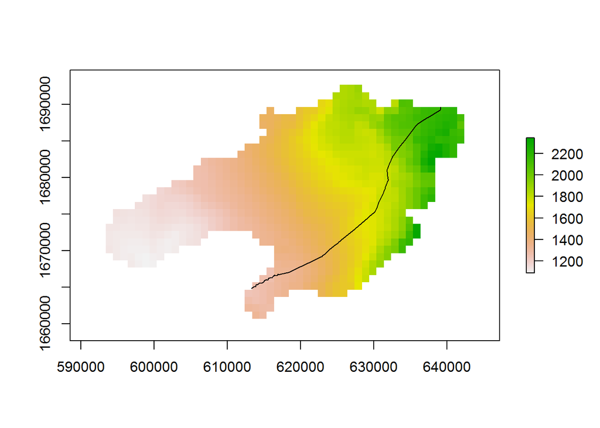

```r
PPT<-raster("rasters/Annualppt1k.tif")
plot(PPT)
lines(Agcor)
```

- From this starting point, create a template raster that will be a distance raster. The following script chunks follow a complete tutorial that is found in resource #4:

```r
r<-PPT
r[]<-NA
Main.road<-rasterize(Agcor, r, field=1)
summary(Main.road)
```

```
##         layer
## Min.        1
## 1st Qu.     1
## Median      1
## 3rd Qu.     1
## Max.        1
## NA's     1984
```

- Now use this object with 1s to create a raster that has pixel values of the distance of that pixel to the main road (in meters):

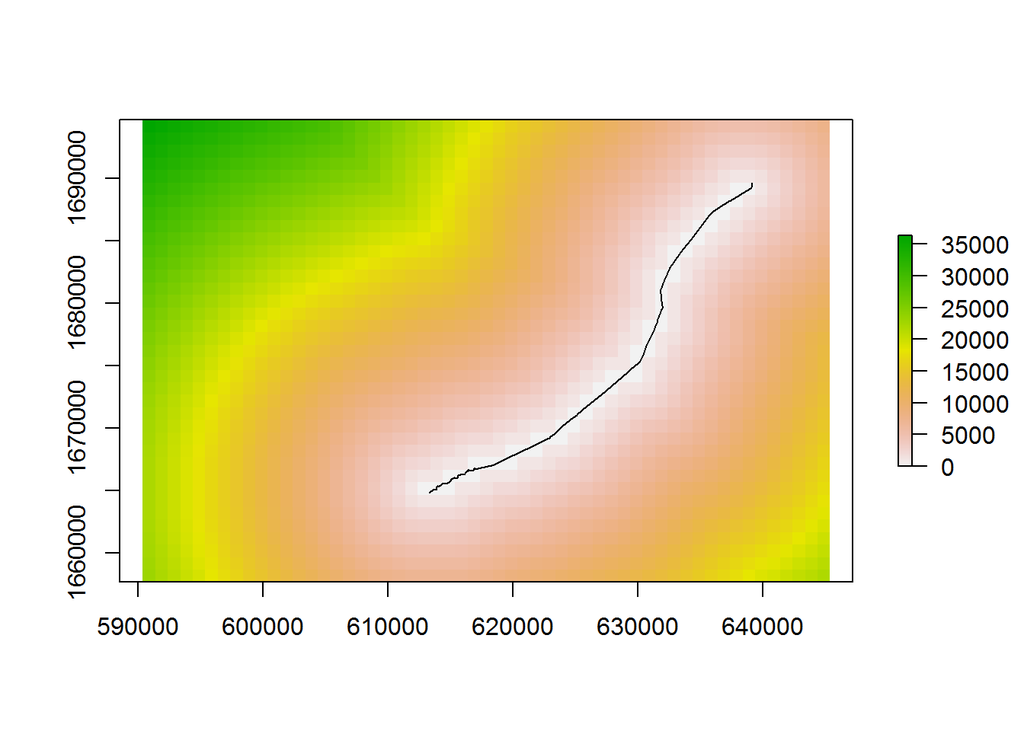

```r
Main.road.distance<-distance(Main.road)
plot(Main.road.distance)
lines(Agcor)
```

- In Km:

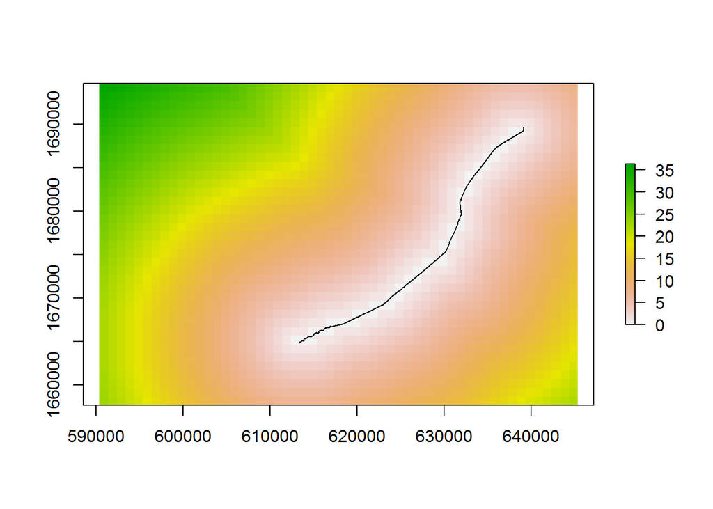

```r
Main.road.distance.km<-Main.road.distance/1000
plot(Main.road.distance.km)
lines(Agcor)
```

- Save the output to a new raster file that can be used outside of the session:

```r
writeRaster(Main.road.distance.km, "DistFromRoadv.tiff", "GTiff")
```